# Model sophistication measure: the Gini Index

January 2016

## Abstract

The AXA Technical Pricing Blueprint written by AGD (AXA 2015) provides the AXA actuarial community with the best practices from across the group to build a technical tariff. As mentioned in this document, the risk model quality can be measured using the Gini index. This KPI aims to assess the ability of the models to properly rank the risks. Additionally, when trying to improve the model by adding variables or simply switching the algorithm, we can assess its efficiency by comparing both models.

After having defined the Gini index and described its fundamentals, we will provide its theoretical calculation. Since the classical Gini index is not appropriate to compare models across perils, we will introduce the Normalized Gini Index, which offers us the opportunity to do so.

Additionally, even though the Gini Index can easily be computed using different software (such as Emblem, Earnix…), we are presenting its numerical calculation, an example R code to reproduce this calculation and plot meaningful graphs to interpret the results can be found in the Code Appendix.

# Introduction

The Gini index is a meaningful KPI to assess the ability of the models to properly rank the risks, *i.e.*, the segmentation quality. It is calculated using the Gain Curve.

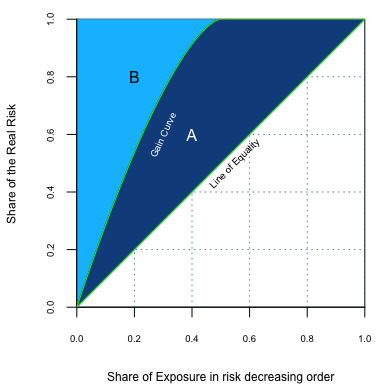

**Figure 1:** Gain curve

The **Gain Curve** is based on the Lorenz theory (Lorenz 1905) which was developed for representing the inequality of the wealth income.

It is presented in the AXA Technical Pricing Blueprint written by AGD (AXA 2015):

> *Usually, the original dataset is split in 2 datasets, one for the training (80%) and one test set (20%). All the models are built on the train dataset and its ability to predict is validated on the test set. The Gini index will be one of the KPI’s used to validate the model. This ensures that it measure the model’s ability to predict and removes distortions from over-fitting.*

> *The Gain curve and the Gini index can be calculated for any predictive model. But the absolute value of the Gini coefficient can vary significantly between different types of perils. This is because of the absolute claims frequency affecting the amount of data, the shape and volatility of the underlying distribution* (see Figure 2 & Figure 3).

> *The nature of the model means that predictions are continuous so a policy is given a probability of having a claims and an expected average cost of that claim. However the Gain curve is built using observed values where some policies do have a claim and the majority does not. Therefore there could be some jumps in the curve due to aggregations of claims or of large losses. These large losses might unduly influence the Gini leading to a volatile metric. Bootstrap sampling can overcome this issue by giving a confidence interval around the observed value.*

Figure 2 shows the impact of the absolute claims frequency on the shape of the curve and its associated Gini index assuming the same cost for all the claims. A similar plot can be done showing the impact of the claim cost distribution on the Gain curve and the Gini index (Figure 3). Those plots show the theoretical maximum Gini index that is reachable for a given type of peril.

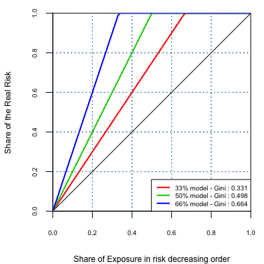

**Figure 2:** Gain Curve for varying claim frequency

On the Figure 3, the *exp* distribution represents the case where the entire cost is concentrated on a few claims.

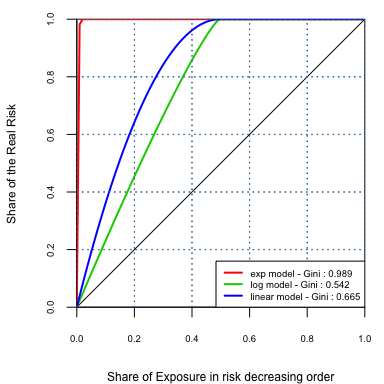

**Figure 3:** Gain curve for varying claims distribution

## Why use it?

This index can be very helpful in assessing the quality of one model and comparing it to the actual one. One can assess the need to add some variables, their impact on the pricing and follow the change of accuracy over time.

## Theoretical calculation

As explained in the first section, the Gini coefficient is computed using the AUC (area under the curve). It is therefore the ratio of the areas in Figure 1.

If the area between the line of perfect equality and the Lorenz curve is A, and the area over the Lorenz curve is B, then the Gini index is defined as $G = \dfrac{A}{A+B}$.

Since A + B = 0.5, the Gini index is $G = 2 A$, or $G = 1 – 2 B$.

If the Lorenz curve is represented by the function $Y = L(X)$, the value of $B$ can be found with integration and:
$$B = 1 - \int_0^1 L(X) dX$$

Finally, the *Gini index* is:
$$G = 2 \int_0^1 L(X) dX -1$$

## How can we compare the Gini index across perils? The Normalized Gini Index

Indeed, as we said, the Gini index depends on the absolute claims frequency which is affected by the amount of data, the shape and volatility of the underlying distribution. Therefore, it does not allow comparison of models across different perils. Thus we are suggesting normalizing the standard Gini index by the Gini index of the observed distribution (deterministic model). This new index is called the **Normalized Gini index**.

Let’s assume we have the following case:

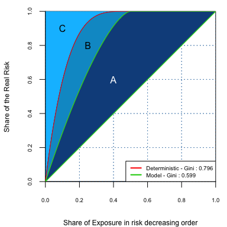

**Figure 4:** Definition of the areas of the Gain curve

We define three sectors on the above graph:

- $A$ the area between the Gain Curve of the model and the bisector,
- $B$ the area between the Gain Curves of the deterministic model and the model built,
- $C$ the area between the Gain Curve of the deterministic model and the upper boundary of the graph.

Using the classical definition of the Gini index $G_I$ (resp. $G_M$) of the deterministic model (resp. of the model) is $G_I = \frac{A+B}{A+B+C}$ (resp. $G_M = \frac{A}{A+B+C}$).

Thus, normalizing the Gini index calculation, we consider the ratio $\widetilde{G}=\frac{G_M}{G_I}$. Using the definition, we obtain directly the **Normalized Gini index**:
$$\widetilde{G}=\frac{A}{A+B}.$$

This new index now lies between 0 and 1, and the higher it is, the better the model segmentation is. With this new index, it is possible to compare different perils and models.

We created functions to plot the deterministic Gain curve and compute the Normalized Gini index (See Code Appendix).

With this new index, we can compute the Normalized Gini index for the previous plot, seeing that even though the standard Gini is at $0.599$, the Gain curve is quite close to the deterministic one. It seems like the model is correctly predicting the risk associated with those images.

We find that the normalized Gini index is $\widetilde{G}=$ 0.753, showing that this model is not bad but could still be improve to be closer to 1.

## Should the Gini index change when doing a new model?

It could happen that after having improved your tariff, you might notice that the Gini index did not change.

In fact, as explained, the Gain curve and the Gini index are only a measure of the proper ordering of the risks. You are not assessing the value of the risks. So you might have the same ordering (kept the same Gini index) but changed the risk amount and improve your tariff. The Gini index is, therefore, not the only measure that needs to be looked at.

The **Explained Deviance Ratio** is defined in the AXA Technical Pricing Blueprint written by AGD (AXA 2015):

> *It compares the explained deviance ratio for the train and the test samples.*

> *Deviance is made up of both signal and random variation. But while the signal is consistent over different sub-samples the random variables is not. As a result, a good model is one where the explained deviance is similar for the train and the test samples. If the ratios are significantly different then the model has captured noise from the train sample and the model is over-fitted. So some factors or interactions need to be reviewed and possibly removed from the model. In this case a factor by factor analysis must be performed on the train sample to identify problem factors and interactions.*

# How to compute the Gini index?

## Operational computing of the Gain curve and the Gini index

Let’s consider a sample of $n$ policies. We will note $E_i$ the exposure of the policy $i$ and $S_i$ its claim amount over the exposure. After modelling the annual pure premium is defined as $PP_i$. Therefore we note $Z_i$ the estimator of $S_i$ defined for each $i$ as
$$Z_i = PP_i\times E_i$$

Noting $Z_{i,n}$ the $i$-order statistic of $\left(Z_i\right)_{i=1,...,n}$ ,$E'_{i}$ the exposure of $Z_{i,n}$ and $S'_{i}$ the real claim amount associated to $Z_{i,n}$, the gain curve is defined joining the following points:
$$\left( \frac{\sum_{j=0}^{i} {E'_{j}} } {E} , \frac{\sum_{j=0}^{i} {S'_{j}}}{S} \right)_{i=0,..,n}$$
where: $E'_{0}=0$, $S'_{0}=0$, $S = \sum_{i = 0}^{n}{S'_{i}}$ and $E = \sum_{i = 0}^{n}{E'_{i}}$.

The R function to compute the trapezoid integral can be found in the Code Appendix and Figure 5 illustrates the concept of the trapezoid rule. We are summing over all the trapezoids under the curve and subtracting the area under the bisector (1/2).

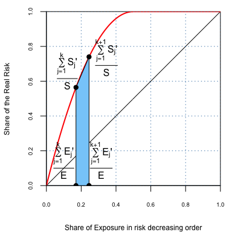

**Figure 5:** Trapezoid rule integration

# Code Appendix: Numerical computation using R

We will define 2 functions for computing both the Gini coefficient and plot the Gain curve, they can be found in the Code Appendix.

### Gain Curve

The following code defines a function that could be used to plot the Gain curve.

```r
#' Gain Curve
#' plots the lorenz curve for the given data
#' @param risk a variable that contains the risk (claims severity for example).
#' @param variables a data.table or data.frame where each column is a variable that rank the risk.
#'
#' @return a plot with all the Gain curve
## Creation of the plot_gain function

plot_gain <- function(risk, ordering,exposure = rep(1, length(risk)))
{

  if(!is(ordering,c("data.table", "data.frame")))
    stop("ordering should be of type data.table or data.frame")
  # Getting the index of the NA's
  ina <- !is.na(risk)
  x = (0:100) / 100
  # Format the plot
  par(xaxs = 'i', yaxs = 'i', oma=c(0,0,0,0), mar=c(4,4,1,1))
  # Plotting the bisector
  plot(x,x, type = "l", xlab = "Share of Exposure in risk decreasing order", ylab = "Share of the Real Risk", cex.lab=0.75,cex.axis=0.6)

  # For each column of the ordering data.frame, we will plot a curve
  for(i in 1:ncol(ordering))
  {
    #Remove the NA's
    n <- order(ordering[[i]][ina], decreasing = T)
    #Convert to numeric
    risk <- as.numeric(risk)[ina]
    # Order the risk using the ordering data
    orderrisk = risk[n]
    # Order the exposure using the ordering data
    orderexposure = exposure[n]
    # Compute the cumulating risk & exposure
    cumrisk = c(0,cumsum(orderrisk)/sum(orderrisk))
    cumexposure = c(0, cumsum(orderexposure)/sum(orderexposure))
    #Draw the curve
    lines(quantile(cumexposure, seq(0,1,0.001)), quantile(cumrisk, seq(0,1,0.001))
          , col = i+1, lwd = 2)
    grid(lwd = 1, col = "steelblue")
  }

}
```

The **plot_gain** function created above allows us to obtain Figure 6:

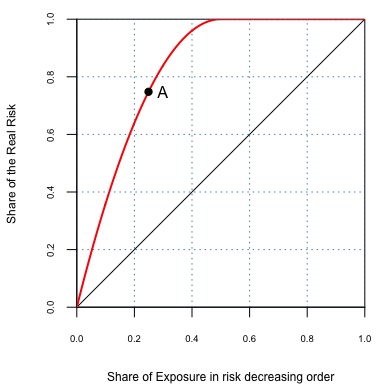

**Figure 6:** Gain Curve

```r
### Plotting using idealized data
l = 100
risk = c(rep(0,l), seq(1,200, length.out = 100))
ordering = data.frame(Model = seq(1,2*l, 1))

plot_gain(risk, ordering)
```

The coordinate of A are given by:
$$x = \frac{\sum_{j=0}^{i} {E'_{j}} } {E}$$
$$y = \frac{\sum_{j=0}^{i} {S'_{j}} } {S}$$

### Gini Index

In order to compute the Gini index, we need first to define a function to compute an area using the trapezoid method. The following code defines this function helping us to obtain the required area:

```r
trapz <- function(x,y){
  # x and y must be vectors
    idx = 2:length(x)
    return (((x[idx] - x[idx-1]) %*% (y[idx] + y[idx-1])) / 2)
  }
```

Using this function, we are now defining the **gini** function computing the Gini index:

```r
# Computes the inequality within a vector according to the Gini Coefficient
gini <- function(risk, ordering, exposure = rep(1, length(risk)))
{

  trapz <- function(x,y){
  # x and y must be vectors
    idx = 2:length(x)
    return (((x[idx] - x[idx-1]) %*% (y[idx] + y[idx-1])) / 2)
  }

  if(!is(ordering,c("data.table", "data.frame")))
    stop("ordering should be of type data.table or data.frame")

  ina <- !is.na(risk)
  x = (0:length(risk)) / length(risk)
  gini = NULL
  for(i in 1:ncol(ordering))
  {
    n <- ordering[[i]][ina]
    risk <- as.numeric(risk)[ina]
    orderrisk = risk[order(n,decreasing = T)]
    cumrisk = c(0,cumsum(orderrisk)/sum(orderrisk))
    exposure <- as.numeric(exposure)[ina]
    orderexposure = exposure[order(n,decreasing = T)]
    cumexposure = c(0,cumsum(orderexposure)/sum(orderexposure))
    gini = c(gini,(trapz(cumexposure, cumrisk)-0.5)/0.5)
  }
  return(gini)
}
```

We call the **gini** function to get the Gini index:

```r
# Compute the Gini index using the predefined function
gini(risk, ordering)
```

```
## [1] 0.6666584
```

Note that adding the following code to the **plot_gain** function will allow us to obtain Figure 7:

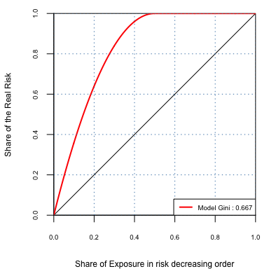

**Figure 7:** Gain Curve with the Gini index

```r
 gini = NULL
  for(i in 1:ncol(ordering))
  {
    # Compute Gini using the Trapezoidal rule
    gini = c(gini,(trapz(cumexposure, cumrisk) -0.5)/0.5)
  }
  # Add a legend
  legend("bottomright",legend = paste0(colnames(ordering), ' Gini : ', round(gini,3)),
         col = 2:(ncol(ordering)+1),lty = c(1,1), lwd = 2, cex=0.6)
```

## Normalized Gini Index

```r
# Computes the inequality within a vector according to the Gini Coefficient
normalized_gini <- function(risk, ordering, exposure = rep(1,length(risk)))
{
  if(!is(ordering,c("data.table", "data.frame")))
    stop("ordering should be of type data.table or data.frame")

  trapz <- function(x,y){
    idx = 2:length(x)
    return (((x[idx] - x[idx-1]) %*% (y[idx] + y[idx-1])) / 2)
  }
  ina <- !is.na(risk)
  #Remove the NA's
  n <- order(risk, decreasing = T)
  #Convert to numeric
  risk <- as.numeric(risk)[ina]
  # Order the risk using the ideal data
  orderrisk = risk[n]
  # Order the exposure using the ideal data
  orderexposure = exposure[n]
  # Compute the cumulating risk
  cumrisk = c(0,cumsum(orderrisk)/sum(orderrisk))
  # Compute the cumulatin exposure
  cumexposure = c(0, cumsum(orderexposure)/sum(orderexposure))
  giniIdeal = (trapz(cumexposure, cumrisk)-0.5)/0.5
  gini = NULL

  for(i in 1:ncol(ordering))
  {
    #Remove the NA's
    n <- order(ordering[[i]][ina], decreasing = T)
    #Convert to numeric
    risk <- as.numeric(risk)[ina]
    # Order the risk using the ordering data
    orderrisk = risk[n]
    # Order the exposure using the ordering data
    orderexposure = exposure[n]
    # Compute the cumulating risk & exposure
    cumrisk = c(0,cumsum(orderrisk)/sum(orderrisk))
    cumexposure = c(0, cumsum(orderexposure)/sum(orderexposure))
    gini = c(gini,(trapz(cumexposure,cumrisk)-0.5)/0.5)
  }
  gini = gini / giniIdeal
  return(gini)
}
```

Note that if one wants to plot the ideal curve and the model curve on the same figure, he could use the following code:

```r
modified_plot_gain <- function(risk, ordering, exposure = rep(1, length(risk)))
{
  if(!is(ordering,c("data.table", "data.frame")))
    stop("ordering should be of type data.table or data.frame")
  trapz <- function(x,y){
    idx = 2:length(x)
    return (((x[idx] - x[idx-1]) %*% (y[idx] + y[idx-1])) / 2)
  }
  # Getting the index of the NA's
  ina <- !is.na(risk)
  x = (0:length(risk)) / length(risk)
  par(xaxs = 'i', yaxs = 'i', oma=c(0,0,0,0), mar=c(4,4,1,1))
  # Plotting the bisector
  plot(x,x, type = "l", xlab = "Share of Exposure in risk decreasing order", ylab = "Share of the Real Risk", cex.lab=0.75,cex.axis=0.6)
  ## Plotting the ideal Gain curve
  #Remove the NA's
  n <- order(risk, decreasing = T)
  #Convert to numeric
  risk <- as.numeric(risk)[ina]
  # Order the risk using the ideal data
  orderrisk = risk[n]
  # Order the exposure using the ideal data
  orderexposure = exposure[n]
  # Compute the cumulating risk
  cumrisk = c(0,cumsum(orderrisk)/sum(orderrisk))
  # Compute the cumulatin exposure
  cumexposure = c(0, cumsum(orderexposure)/sum(orderexposure))
  #Draw the curve
  lines(quantile(cumexposure, seq(0,1,0.001)),
        quantile(cumrisk, seq(0,1,0.001)), col = 'darkblue', lwd = 2)
  # Compute Gini using the Trapezoidal rule
  giniIdeal = (trapz(cumexposure, cumrisk) -0.5)/0.5
  ## Plot the curve for the models
  gini = NULL
  # For each column of the ordering data.frame, we will plot a curve
  for(i in 1:ncol(ordering))
  {
    #Remove the NA's
    n <- order(ordering[[i]][ina], decreasing = T)
    #Convert to numeric
    risk <- as.numeric(risk)[ina]
    # Order the risk using the ordering data
    orderrisk = risk[n]
    # Order the exposure using the ordering data
    orderexposure = exposure[n]
    # Compute the cumulating risk & exposure
    cumrisk = c(0,cumsum(orderrisk)/sum(orderrisk))
    cumexposure = c(0, cumsum(orderexposure)/sum(orderexposure))
    #Draw the curve
    lines(quantile(cumexposure, seq(0,1,0.001)), quantile(cumrisk, seq(0,1,0.001)), col = i+1, lwd = 2)
    # Compute the Gini index for this ordering using the Trapezoidal rule
    gini = c(gini, (trapz(cumexposure, cumrisk) -0.5)/0.5)
    grid(lwd = 1, col = "steelblue")
  }
  gini = gini / giniIdeal
  # Add a legend
  legend("bottomright",legend = c('Ideal curve',paste0(colnames(ordering), ' - Modified Gini : ', round(gini,3))),col = c('Darkblue',2:(ncol(ordering)+1)),lty = c(1,1), lwd = 2, cex=0.6)
}
```

## Example using a Gradient Boosting Algorithm

Using an actual dataset, we can illustrate how those functions are working.

```r
setDT(data)
# Take only a sample of the data
data$real_exposure = data$exposure
data <- data[sample(nrow(data), 350000), ]
# Select the variables
candidateVariables = c("gender","marital_status", "bonus_malus",
                       "chassis", "energy","body", "BHP",
                       "transmission", "age_owner","CC", "city_owner")
# Convert the class from character to factors
for( col in 1:ncol(data)){
  if(class(data[[col]]) == 'character'){
    data[, eval(colnames(data)[col]) := as.factor(get(colnames(data)[col]))]
  }
}
train_sample=sample(1:nrow(data),size=0.8*nrow(data))
train=data[train_sample,]
test=data[-train_sample,]
test=droplevels(test)
train=droplevels(train)

# Run a gradient boosting on candidateVariables
fgbm = gbm(claim~. , train[, c(candidateVariables, "claim", "exposure"), with=F], n.trees = 50, interaction.depth = 5,
           shrinkage = 0.06,verbose = T, distribution = "bernoulli")
# Predict the frequency
test$exposure = 1
frequency_prediction_gbm <- predict(fgbm, test, n.trees = 50, type = "response")

# Gradient boosting for the severity
sgbm = gbm(claim_cost ~. , train[claim_cost > 0, c(candidateVariables, "claim_cost"),with=F],n.trees = 50,
           interaction.depth = 5, shrinkage = 0.03,verbose=T, distribution="laplace")
```

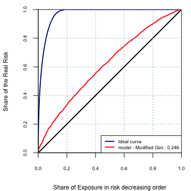

**Figure 8:** Gain Curve in a practical case

```r
# Predict the severity
severity_prediction_gbm = predict(sgbm, test, n.trees = 50, type = "response")

modified_plot_gain(test$claim_cost, data.frame(model = severity_prediction_gbm * frequency_prediction_gbm), exposure = test$real_exposure)
```

```r
normalized_gini(test$claim_cost, data.frame(model = severity_prediction_gbm * frequency_prediction_gbm), exposure = test$real_exposure)
```

```
##           [,1]
## [1,] 0.2456887
```

# Reference

AXA, Global Direct. 2015. “AGD Pricing Best Practices; Blueprint 1: Technical Pricing.”

Lorenz, Max O. 1905. “Methods of Measuring the Concentration of Wealth.” *Publications of the American Statistical Association* 9 (70). Taylor & Francis: 209–19.